# New interpretation double-sampling

Mixing field protocols and lab methods

Note’s with example of the interpretation of double-sampling in the SoilHarmony project.

Previously, we were under the impression that double-sampling meant that at one location, a single field protocol would be used to collect a compound sample based on a mixture of sub-samples, that this compound sample would be split in half and that each half would be analysed with two different lab methods and that a TF should make the translation between two lab methods (for a fixed field protocol).

Recently, it became clear that the interpretation is different: namely that at each location, two field protocols are applied and each field protocol collects a different compound sample. This means the TF should translate a pair (field protocol 1, non-reference method) -> (field protocol 2, reference method).

Notation and concepts:

- point values of the soil descriptor - values at point locations the size of the sampling equipment, eg. 1 cm² - have a variance in the population (area $A$) of $\sigma^2(p, A)$
- the variance of the average per location in the population, $\sigma^2(a, A)$, decreases with size of the area of the location: as $a$ -> $A$, $\sigma^2(a, A)$ -> 0
- the variance of the point values within a location, $\sigma^2(p, a)$, increases with size of the area of the location: as $a$ -> $A$, $\sigma^2(p, a)$ -> $\sigma^2(p, A)$
- Krige’s relation says the total remains constant: $\sigma^2(p, A) = \sigma^2(a, A) + \sigma^2(p, a)$
- assuming that variance of the average per location is proportional to area: $\sigma^2(a, A) \propto a^{-\alpha}$ ($\alpha$ = scaling exponent (0 < $\alpha$ < 1) defines spatial autocorrelation), we can see that the variances of the average per location are related to each other: $\sigma^2(a2, A) = \sigma^2(a1, A) \left(\frac{a_1}{a_2}\right)^{\alpha}$

```r
library(tidyverse)
```

Let’s say we double-sample $N$ locations.

```r
N <- 200
```

Protocol 1 = LUCAS ($a_1$ = 4$\pi$ m², $n_1$ = 5 sub-samples) Protocol 2 = CMON ($a_2$ = 100 m², $n_2$ = 16 sub-samples)

Let’s say we examine soil pH:

- mean in the population: $\mu$ = 7
- variance of point-values in the population: $\sigma^2(p, A)$ = 2
- for LUCAS the variance of latent support-area averages: $\sigma^2(a_1, A)$ = 1.9
- spatial autocorrelation: $\alpha$ = 0.1 (smooth)

```r
# assumptions
mu_x            <- 7
sigma2_pA       <- 2
sigma2_support1 <- 1.9
spatautocor     <- 0.1

# field protocols
a1 <- 4 * pi
a2 <- 100
n1 <- 5
n2 <- 16

# variance of support-average values (protocol 2)
R_a             <- (a1 / a2)^spatautocor
sigma2_support2 <- sigma2_support1 * R_a

# variance of within-support point values (Krige's relation)
sigma2_wpoint1 <- sigma2_pA - sigma2_support1
sigma2_wpoint2 <- sigma2_pA - sigma2_support2

# sampling variance from taking n sub-samples within the support:
sigma2_sampling1 <- sigma2_wpoint1 / n1
sigma2_sampling2 <- sigma2_wpoint2 / n2
```

Let’s assume the correlation between the latent support-average values for the non-reference method is high: although the CMON area is much larger, the non-overlapping part does not shift the support-average value by a lot or in a systematic manner.

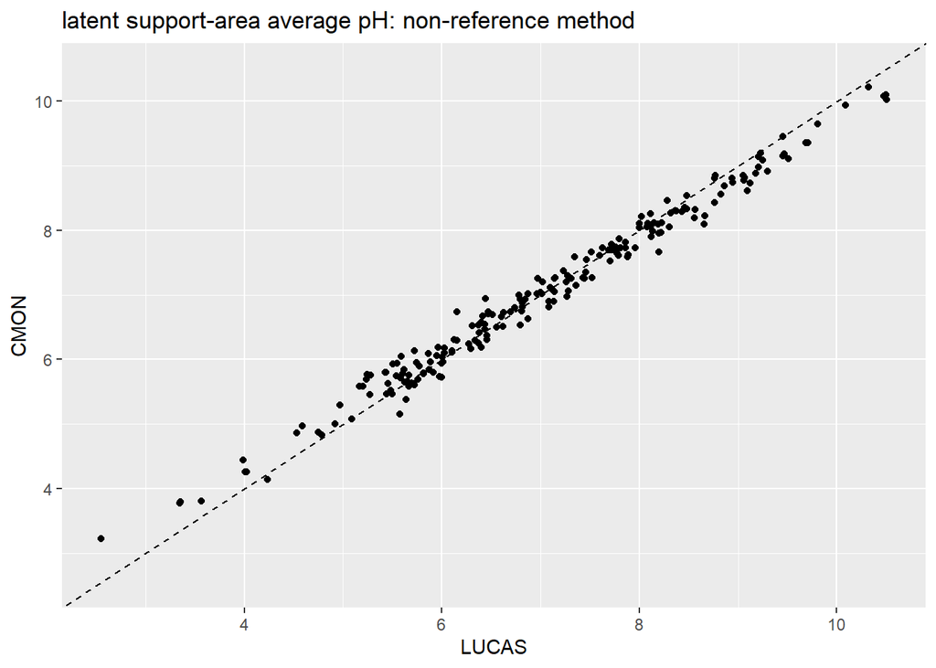

```r
# assumptions
corr_latent <- .99

# simulate latent support-average values for the non-reference method
# we simulate the non-reference method in both protocols
# in a later phase, we will ignore this method in 1 of the protocols
var_latent <- matrix(
    c(sigma2_support1,
      rep(sqrt(sigma2_support1 * sigma2_support2) * corr_latent, 2),
      sigma2_support2),
    byrow = TRUE, nrow = 2
  )
latent_x <- MASS::mvrnorm(N, rep(mu_x, 2), var_latent) |>
  as.data.frame()

ggplot(latent_x, aes(V1, V2)) +
  geom_point() +
  geom_abline(intercept = 0, slope = 1, lty = 2) +
  labs(x = "LUCAS", y = "CMON",
       title = "latent support-area average pH: non-reference method") +
  xlim(min(latent_x), max(latent_x)) + ylim(min(latent_x), max(latent_x))
```

Let’s assume there is a linear TF between the latent support-area averages of the non-reference method and reference method:

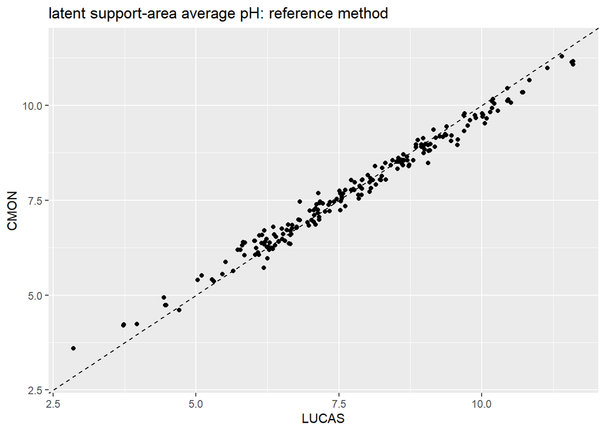

```r
# assumptions
beta0 <- 0.05
beta1 <- 1.1

# TF from the non-reference method to the reference method with both protocols
latent_y <- beta0 + beta1 * latent_x

ggplot(latent_y, aes(V1, V2)) +
  geom_point() +
  geom_abline(intercept = 0, slope = 1, lty = 2) +
  labs(x = "LUCAS", y = "CMON",
       title = "latent support-area average pH: reference method") +
  xlim(min(latent_y), max(latent_y)) + ylim(min(latent_y), max(latent_y))
```

```r
# mixing method and protocol in outcome and predictor makes we cannot recover
# the regression coefficients
# and that's before adding measurement error
lm(latent_y$V1 ~ latent_x$V2)
```

```
Call:
lm(formula = latent_y$V1 ~ latent_x$V2)

Coefficients:
(Intercept)  latent_x$V2
    -0.6831       1.2057
```

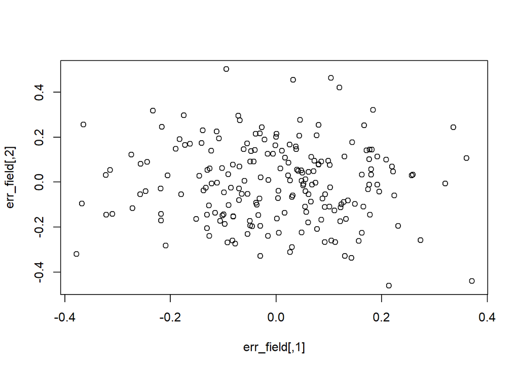

```r
# assumption
corr_mefield <- 0

# field sub-sampling error (approximating support mean with n sub-samples)
varme_field <- matrix(
  c(sigma2_sampling1,
    rep(sqrt(sigma2_sampling1 * sigma2_sampling2) * corr_mefield, 2),
    sigma2_sampling2),
  byrow = TRUE, nrow = 2
)

err_field <- MASS::mvrnorm(N, rep(0, 2), varme_field)
plot(err_field)
```

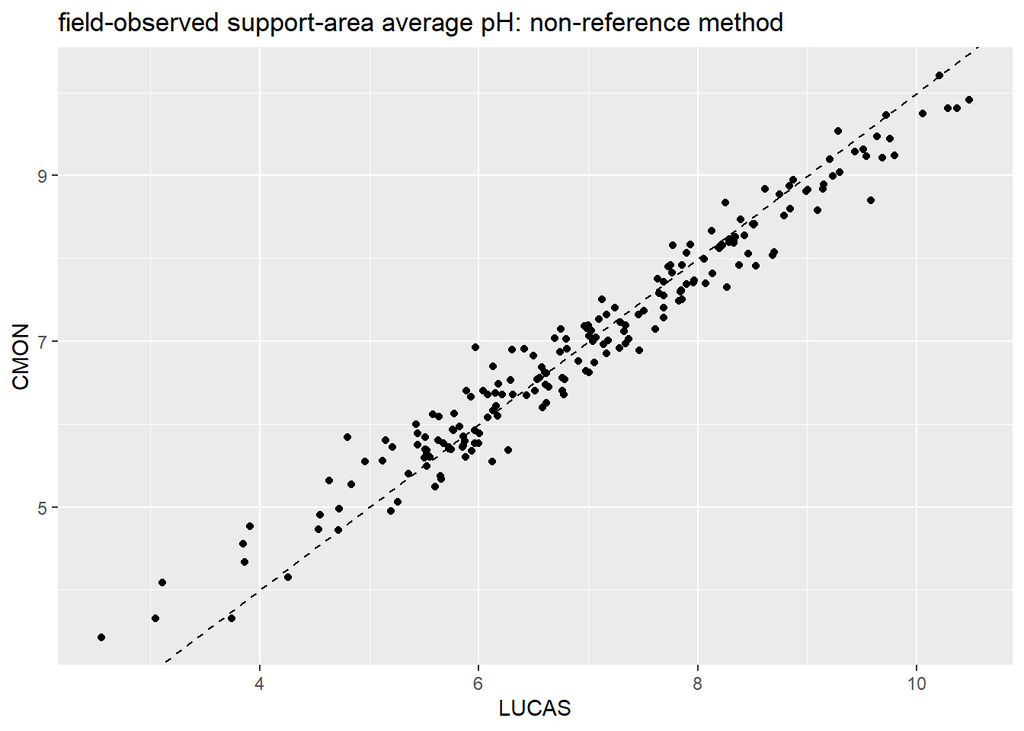

```r
# obs_field_% is what we would observe if there was no lab measurement error
obs_field_x <- latent_x + err_field
obs_field_y <- latent_y + err_field


ggplot(obs_field_x, aes(V1, V2)) +
  geom_point() +
  geom_abline(intercept = 0, slope = 1, lty = 2) +
  labs(x = "LUCAS", y = "CMON",
       title = "field-observed support-area average pH: non-reference method")
```

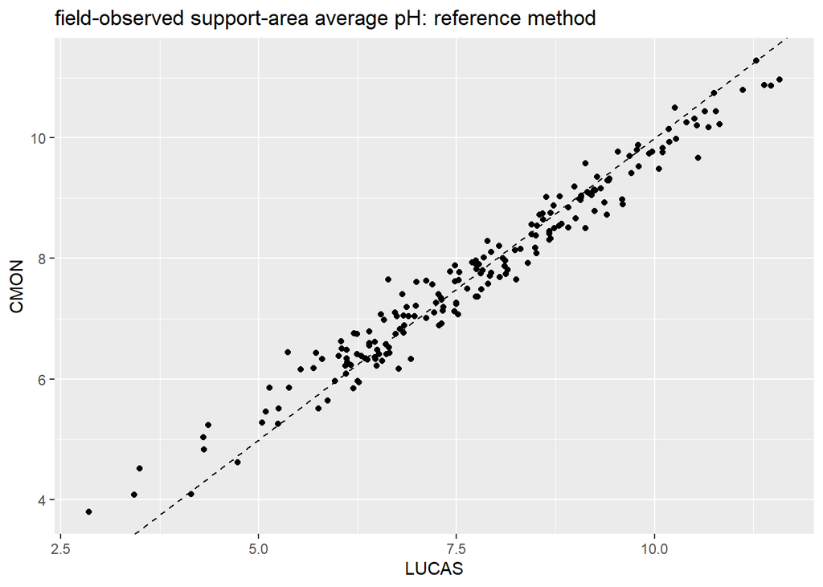

```r
ggplot(obs_field_y, aes(V1, V2)) +
  geom_point() +
  geom_abline(intercept = 0, slope = 1, lty = 2) +
  labs(x = "LUCAS", y = "CMON",
       title = "field-observed support-area average pH: reference method")
```

Next we add lab measurement error. Let’s assume that the lab measurement error is much smaller than the field measurement error (eg. 5%). Let’s assume that the lab measurement error of reference- and non-reference methods are equal. Let’s assume there is no correlation between the lab measurement errors. With split-samples a correlation could be expected from shared pre-processing of compound samples, but with separate compound samples, I don’t see how the lab measurement errors can be correlated.

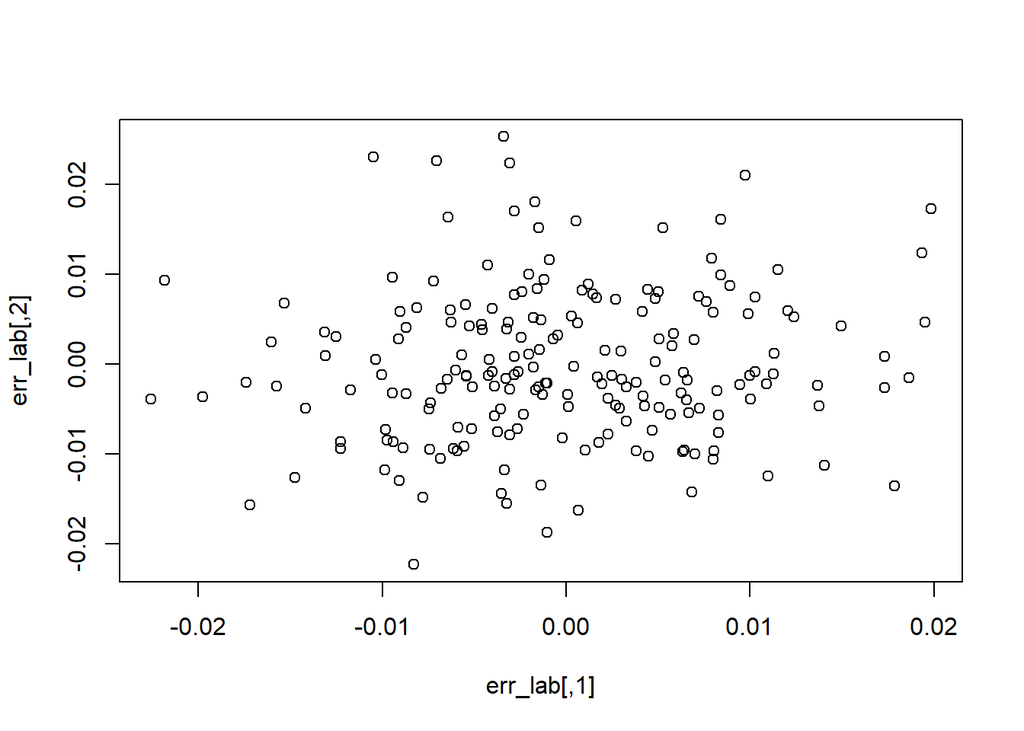

```r
# assumptions
corr_melab            <- 0
ratio_labmex_fieldmex <- .05
ratio_labmey_labmex   <- 1
sd_lab_mex            <- ratio_labmex_fieldmex * sqrt(sigma2_sampling2)
sd_lab_mey            <- ratio_labmey_labmex * sd_lab_mex

varme_lab  <- matrix(
  c(sd_lab_mex^2, rep(sd_lab_mex * sd_lab_mey * corr_melab, 2), sd_lab_mey^2),
  byrow = TRUE, nrow = 2
)
err_lab   <- MASS::mvrnorm(N, rep(0, 2), varme_lab)
obs_lab_x <- obs_field_x + err_lab
obs_lab_y <- obs_field_y + err_lab


plot(err_lab)
```

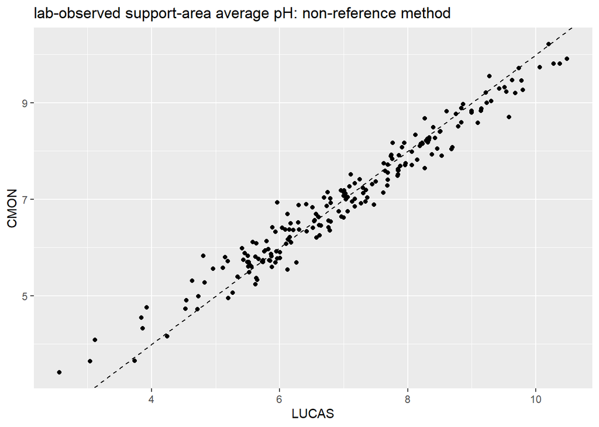

```r
ggplot(obs_lab_x, aes(V1, V2)) +
  geom_point() +
  geom_abline(intercept = 0, slope = 1, lty = 2) +
  labs(x = "LUCAS", y = "CMON",
       title = "lab-observed support-area average pH: non-reference method")
```

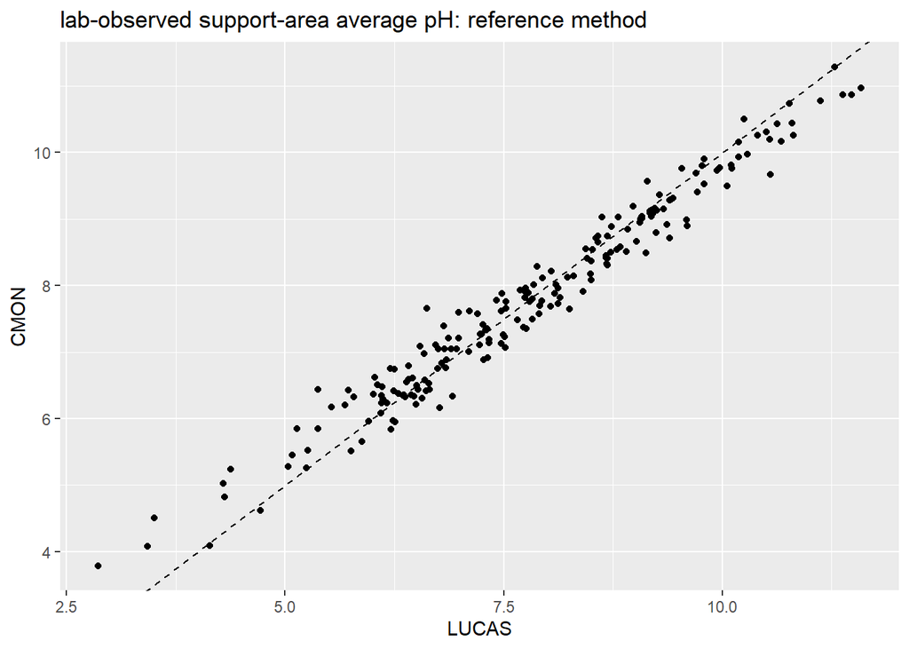

```r
ggplot(obs_lab_y, aes(V1, V2)) +
  geom_point() +
  geom_abline(intercept = 0, slope = 1, lty = 2) +
  labs(x = "LUCAS", y = "CMON",
       title = "lab-observed support-area average pH: reference method")
```

In the end, we only observe 1 method from each protocol.

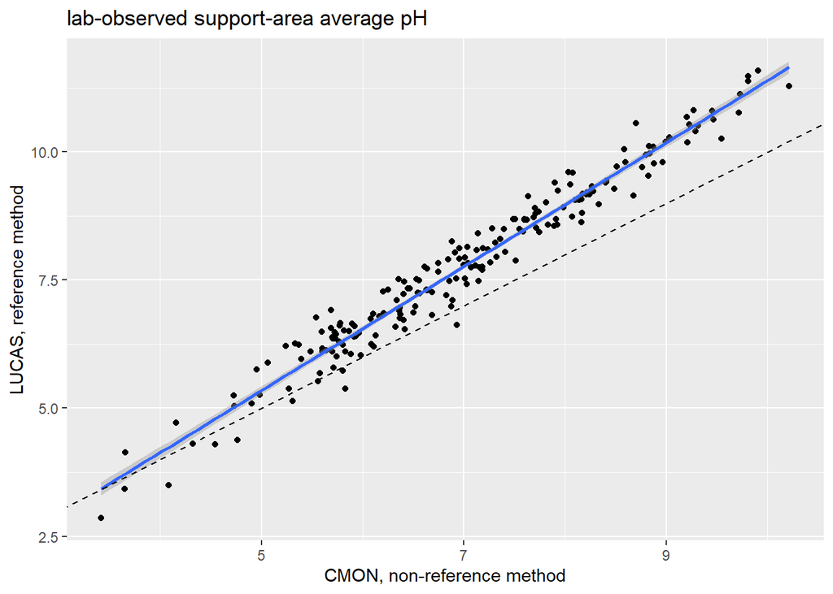

```r
latent <- data.frame(
  CMON_nonref = latent_x$V2,
  LUCAS_ref   = latent_y$V1
)

observed <- data.frame(
  CMON_nonref = obs_lab_x$V2,
  LUCAS_ref   = obs_lab_y$V1
)

ggplot(observed, aes(CMON_nonref, LUCAS_ref)) +
  geom_point() +
  geom_smooth(method = "lm") +
  geom_abline(intercept = 0, slope = 1, lty = 2) +
  labs(x = "CMON, non-reference method", y = "LUCAS, reference method",
       title = "lab-observed support-area average pH")
```

If we make a TF with these observed values, the predictions would only be valid for the exact same pair: (field protocol 1, nonref method 1) -> (field protocol 2, ref method 2) This would mean that European-wide TF’s would be very rare if not impossible if all countries have slightly different field protocols.

```r
mod <- lm(
  LUCAS_ref ~ 1 + CMON_nonref,
  data = observed
)
summary(mod)
```

```
Call:
lm(formula = LUCAS_ref ~ 1 + CMON_nonref, data = observed)

Residuals:
     Min       1Q   Median       3Q      Max
-1.05474 -0.23098  0.00762  0.21743  0.77311

Coefficients:
            Estimate Std. Error t value Pr(>|t|)
(Intercept) -0.70436    0.12231  -5.759 3.19e-08 ***
CMON_nonref  1.20949    0.01714  70.561  < 2e-16 ***
---
Signif. codes:  0 '***' 0.001 '**' 0.01 '*' 0.05 '.' 0.1 ' ' 1

Residual standard error: 0.3325 on 198 degrees of freedom
Multiple R-squared:  0.9618,    Adjusted R-squared:  0.9616
F-statistic:  4979 on 1 and 198 DF,  p-value: < 2.2e-16
```

```r
confint(mod)
```

```
                2.5 %     97.5 %
(Intercept) -0.945557 -0.4631686
CMON_nonref  1.175686  1.2432910
```

Can/should the TF account for this mixture of field/lab protocols?

Next we simulate a validation dataset with the same DGM and try to predict the values with the above model.

```r
N_val        <- 1e4
latent_x_val <- MASS::mvrnorm(N_val, rep(mu_x, 2), var_latent) |>
  as.data.frame()
latent_y_val    <- beta0 + beta1 * latent_x_val
err_field_val   <- MASS::mvrnorm(N_val, rep(0, 2), varme_field)
obs_field_x_val <- latent_x_val + err_field_val
obs_field_y_val <- latent_y_val + err_field_val
err_lab_val     <- MASS::mvrnorm(N_val, rep(0, 2), varme_lab)
obs_lab_x_val   <- obs_field_x_val + err_lab_val
obs_lab_y_val   <- obs_field_y_val + err_lab_val

observed_val <- data.frame(
  CMON_nonref = obs_lab_x_val$V2,
  LUCAS_ref   = obs_lab_y_val$V1
)

predicted_val <- predict(
  mod, newdata = observed_val, interval = "prediction"
) |> as.data.frame()

# nominal coverage? yes
mean( between(observed_val$LUCAS_ref, predicted_val$lwr, predicted_val$upr) )
```

```
[1] 0.9524
```

Making the TF unnecessary complex by trying to account for measurement error? Linear regression seems to do the trick.

EIV-models would need even more parameters as before, making it even more un-identifiable probably.